# Assessment

Stella Doherty

2024-11-01

# Introduction

**Research question:** Did the COVID-19 pandemic influence prescriptions of Selective serotonin reuptake inhibitors (SSRI) antidepressants within Scotland?

This research will focus on prescribing patterns of SSRI antidepressants in different Health Boards across various Health Boards in Scotland pre-COVID (December 2019) versus peak-COVID (December 2020). Focus will be on the trends of prescriptions over the two years and whether different regions in Scotland have higher dependencies on SSRI antidepressants. I am interested in this research from a societal and personal aspect. Since the pandemic was very sudden and an unfamiliar occurrence which quickly altered peoples lives, I am curious how it affected peoples well-being. Also being from Scotland myself, I am interested in understanding the difference location makes for prescriptions like antidepressants. I decided to choose the month of December since the COVID-19 pandemic had been ongoing for a few months before December 2019 so it gives a better perspective as to the growing psychological effect the pandemic was having across the Scottish population.

## Data Wrangling - Prescriptions from December 2019 and 2020

**Load** in required packages:

```r
library(tidyverse)
library(janitor) # examine and clean data
library(gt) # create tables
library(here) # locate files
library(sf) # work with spatial vector data
library(lubridate) # manipulate dates
library(scales)
```

**Read** in prescription data sets:

- Data sets were obtained from opendata.nhs.scot and downloaded in csv format.
- Link to Data by Prescriber Location - December 2019: https://www.opendata.nhs.scot/dataset/prescriptions-in-the-community/resource/fa276ad2-669a-472f-9c47-809f199fae21
- Link to Data by Prescriber Location - December 2020: https://www.opendata.nhs.scot/dataset/prescriptions-in-the-community/resource/0c033702-4d88-4f2d-989c-a709b1f4529e

```r
data_dec2019 <- read_csv(here("data", "opendata_prescriptions_dec2019.csv")) %>%
  clean_names() # cleans variable names

data_dec2020 <- read_csv(here("data", "opendata_prescriptions_dec2020.csv")) %>%
  clean_names()
```

**Display** initial findings:

1. **Join** both prescription data sets together
2. **Filter** for SSRI depressant prescriptions: Citalopram, Dapoxetine, Escaitalopram, Fluoxetine, Fluvoxamine, Paroxetine, Sertraline and Vortioxetine. These are the SSRIs that are currently prescribed in the UK (National Health Service, 2021).
3. Create a **table** presenting the top 5 most prescribed SSRIs

```r
all_prescriptions <- data_dec2019 %>%
  rename(hbt = "hbt2014") %>% # ensures both health board variables have the same name for joining
  full_join(data_dec2020) # full join to retain all data

ssri_all_prescriptions <- all_prescriptions %>%
  filter(!is.na(bnf_item_description), str_detect(bnf_item_description, "FLUOXETINE|CITALOPRAM|ESCAITALOPRAM|PAROXETINE|SERTRALINE|DAPOXETINE|FLUVOXAMINE|VORTIOXETINE")) %>% # removes rows where no item description is present and filters for SSRIs
  select(hbt, bnf_item_description, number_of_paid_items, paid_date_month)


ssri_all_prescriptions_table <- ssri_all_prescriptions %>%
  mutate(paid_date_month = as.Date(paste0(paid_date_month, "01"), format = "%Y%m%d")) %>% # ensures the date is the the form year-month-day instead of a number
  group_by(bnf_item_description, paid_date_month) %>%
  summarise(quantity_sum = sum(number_of_paid_items)) %>% # create total number of prescriptions for all health boards
  arrange(-quantity_sum) %>%
  head(n = 10)

ssri_all_prescriptions_table%>%
  gt(groupname_col = "bnf_item_description",
     row_group_as_column = TRUE) %>% # groups by SSRI prescription and put into a column
  cols_label(quantity_sum = "Total prescriptions",
             paid_date_month = "Year") %>%
  tab_stubhead(label = "SSRI prescription") %>%
  tab_header(title = md("**Top 5 SSRI prescriptions**"),
             subtitle = md("December 2019 *vs* December 2020 across the whole of Scotland")) %>%
  fmt_date(columns = paid_date_month,
           date_style = "yMMM") %>%
  cols_align(align = "center",
             columns = paid_date_month)
```

**Top 5 SSRI prescriptions**

December 2019 *vs* December 2020 across the whole of Scotland

| SSRI prescription | Year | Total prescriptions |
| --- | --- | --- |
| FLUOXETINE HCL_CAP 20MG | Dec 2020 | 81627 |
|  | Dec 2019 | 75661 |
| SERTRALINE HCL_TAB 50MG | Dec 2020 | 77346 |
|  | Dec 2019 | 68501 |
| SERTRALINE HCL_TAB 100MG | Dec 2020 | 76181 |
|  | Dec 2019 | 65944 |
| CITALOPRAM HYDROB_TAB 20MG | Dec 2020 | 54780 |
|  | Dec 2019 | 52599 |
| CITALOPRAM HYDROB_TAB 10MG | Dec 2020 | 27187 |
|  | Dec 2019 | 25836 |

### Table results

**Table of top 5 SSRI prescriptions:** This table ranks SSRIs first, according to most prescribed SSRI prescriptions, then by the year in which had the most of the prescribed SSRI. It shows that shows that for each of prescription shown, December 2020 consistently had a greater number of prescriptions compared to December 2019. From this initial look into the differences pre-COVID versus peak-COVID it suggests that the pandemic is likely affecting the mentaland psycholgoical well-being of the Scottish population.

## Data Wrangling - Prescriptions from December 2019 and 2020 combined with Scottish Health Board and population data

**Load and join data:**

1. Load in Scottish NHS health boards and general census data - join together
2. Join with SSRI prescription data
- Data sets were obtained from opendata.nhs.scot and [Scotlandcensus.gov.uk](https://www.scotlandscensus.gov.uk) and downloaded in csv format.
- Link to Health Board 2014 - Health Board 2019 data: https://www.opendata.nhs.scot/dataset/geography-codes-and-labels/resource/652ff726-e676-4a20-abda-435b98dd7bdc
- To download General Health data:
  - Go to Scotland Census website: https://www.scotlandscensus.gov.uk
  - Navigate to Census data tab at top
  - Select 2022 then ‘Search data by topic’
  - Select ‘Health, Disability and unpaid care’
  - Select ‘General Health UV302’
  - Select ‘Data Zone 2011’
  - Select ‘Select all’

```r
health_boards <- read_csv("https://www.opendata.nhs.scot/dataset/9f942fdb-e59e-44f5-b534-d6e17229cc7b/resource/652ff726-e676-4a20-abda-435b98dd7bdc/download/hb14_hb19.csv") %>%
  clean_names()

hb_general_health <- read_csv(here("data", "UV302_general_health.csv"), skip = 10) %>%
  clean_names() %>% # remove the first row (with extraneous information)
  select(-x5) %>%  # remove the final (unnecessary) column
  rename(hb_name = "health_board_area_2019",
         hb_population = count) %>%
  filter(general_health == "All people") %>% # filter the data so that we get the population of the entire health board
  select(hb_name, hb_population) %>%
  mutate(hb_name = paste("NHS", hb_name)) # change health board names so they match the prescription data
joined_hb_data <- health_boards %>%
  left_join(hb_general_health, by = "hb_name") %>% # left join to only add matching data from general health census to health board data
  select(hb, hb_name, hb_population) %>%
  rename(hbt = "hb")

hb_ssri_all_prescrirptions <- ssri_all_prescriptions %>%
  left_join(joined_hb_data, by = "hbt") %>% # left join to only add matching data from the new joined health board data to the existing SSRI prescription data
  na.omit() %>% # ignores any NA values
  select(-hbt)
```

**Calculate sum of SSRIs and prescriptions per 1k people:**

```r
ssri_sums_item <- hb_ssri_all_prescrirptions %>%
  group_by(paid_date_month, hb_name, bnf_item_description) %>%
  summarise(quantity_sum = sum(number_of_paid_items))

wider_ssri_sums <- ssri_sums_item %>%
  pivot_wider(names_from = bnf_item_description, values_from = quantity_sum)

ssri_sums_total <- wider_ssri_sums %>%
  ungroup() %>%
  mutate(Citalopram = rowSums(select(., starts_with("CITALOPRAM")), na.rm = TRUE),
         Dapoxetine = rowSums(select(., starts_with("DAPOXETINE")), na.rm = TRUE),
         Escaitalopram = rowSums(select(., starts_with("ESCITALOPRAM")), na.rm = TRUE),
         Fluoxetine = rowSums(select(., starts_with("FLUOXETINE")), na.rm = TRUE),
         Fluvoxamine = rowSums(select(., starts_with("FLUVOXAMINE")), na.rm = TRUE),
         Paroxetine = rowSums(select(., starts_with("PAROXETINE")), na.rm = TRUE),
         Sertraline = rowSums(select(., starts_with("SERTRALINE")), na.rm = TRUE),
         Vortioxetine = rowSums(select(., starts_with("VORTIOXETINE")), na.rm = TRUE))

longer_ssri_sums_total <- ssri_sums_total %>%
  select(hb_name, paid_date_month, Citalopram, Dapoxetine, Escaitalopram, Fluoxetine, Fluvoxamine, Paroxetine, Sertraline, Vortioxetine) %>%
  pivot_longer(cols = Citalopram:Vortioxetine, names_to = "ssri", values_to = "sum")

# Calculate total sum of SSRI prescriptions per 1000 people
ssri_per_1k <- longer_ssri_sums_total %>%
  left_join(hb_general_health) %>%
  # calculate total per 1k, rounding to 2 decimal places
  mutate(ssri_per_1k = round((sum/hb_population)*1000, 2),
         paid_date_month = ym(paid_date_month),
         paid_date_month = year(paid_date_month))%>%
  select(-sum, -hb_population)
```

## Data presentation - Graph and Map

Present a **graph** of SSRI prescriptions comparing numbers prescribed per 1k in December 2019 vs 2020, including all Scottish health boards:

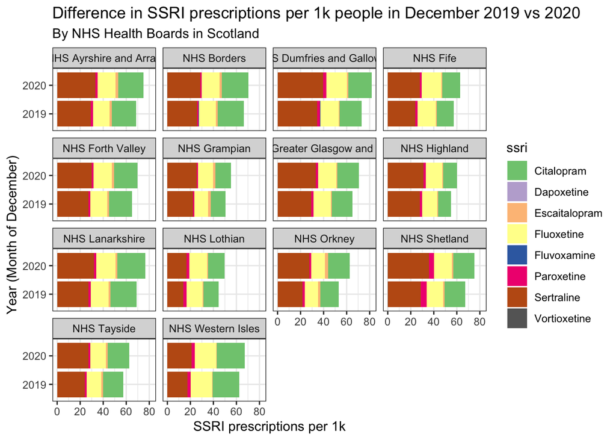

```r
ssri_per_1k %>%
  ggplot(aes(x = reorder(factor(paid_date_month), ssri_per_1k),
              y = ssri_per_1k, fill = ssri)) +
  geom_bar(stat = "identity", position = "stack")+
  facet_wrap(~hb_name)+
  coord_flip()+ # Flip the axes of the plot
  labs(title = "Difference in SSRI prescriptions per 1k people in December 2019 vs 2020",
       subtitle = "By NHS Health Boards in Scotland",
       x = "Year (Month of December)",
       y = "SSRI prescriptions per 1k")+
  scale_fill_brewer(palette = "Accent")+
  theme_bw()
```

### Graph results

This graph presents the number of each SSRI prescriptions per 1,000 people from December 2019 and December 2020, with a separate view of each Health Board in Scotland. In every Health Board the number of prescriptions have increased from 2019 to 2020 with similar patterns observed between the two years for each health board. This further builds on the negative effect of the pandemic and likely has a similar effect on all areas across Scotland in regards to peoples mental and psychological well-being. This consistency of increased prescriptions across all areas of Scotland shows the national impact of the pandemic and suggests that the population is similarly being challenged by isolation, stress and unknown future outcomes of the disease.

**Mapping:**

Load in geospatial data:

- Link to Geospatial data for NHS Health Boards - Scotland: https://www.spatialdata.gov.scot/geonetwork/srv/eng/catalog.search#/metadata/f12c3826-4b4b-40e6-bf4f-77b9ed01dc14

```r
hb_geo_data <- st_read(here("data" ,"SG_NHS_HealthBoards_2019")) %>%
  clean_names() %>%
  mutate(hb_name = paste("NHS ", hb_name, sep = ""))
```

Join geospatial data with SSRI prescriptions per 1000 people:

```r
joined_geo_sums <- full_join(ssri_per_1k, hb_geo_data, by = "hb_name")

joined_geo_sums <- st_as_sf(joined_geo_sums) # ensure joined data set is in the form sf for geosptial plotting
```

Present map of SSRI prescription data across NHS Health Boards Scotland:

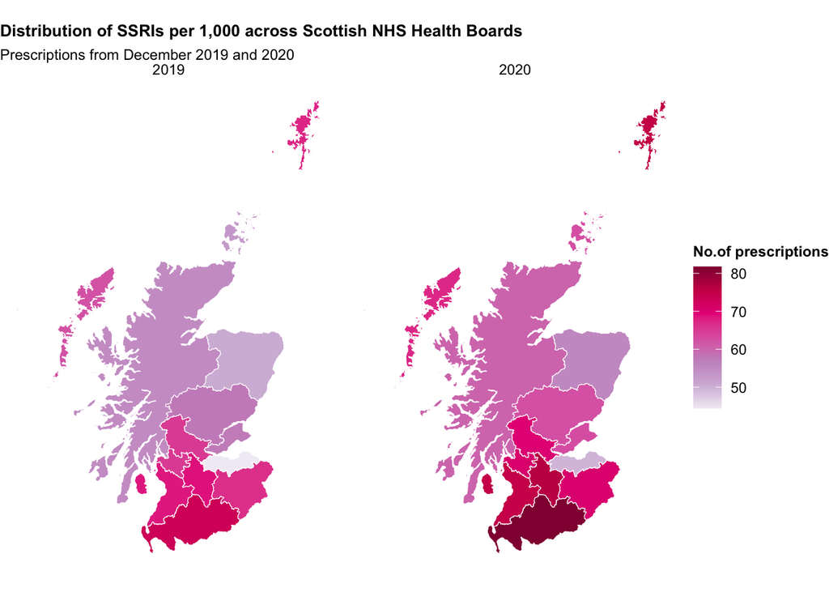

```r
total_map_sums <- joined_geo_sums %>%
  group_by(hb_name, paid_date_month, geometry) %>%
  summarise(total_ssri_per_1k = sum(ssri_per_1k, na.rm = TRUE)) %>%
  ungroup()

ssri_map <- total_map_sums %>%
  ggplot(aes(fill = total_ssri_per_1k))+
  geom_sf(colour = "white", linewidth = 0.2)+
  scale_fill_distiller(palette = "PuRd", direction = 1) +
  theme_void()+
  labs(title = "Distribution of SSRIs per 1,000 across Scottish NHS Health Boards",
       subtitle = "Prescriptions from December 2019 and 2020",
       fill = "No.of prescriptions")+
  theme(plot.title = element_text(face = "bold", size = 10),
        plot.subtitle = element_text(size = 9),
        legend.title = element_text(face = "bold", size = 9))+
  facet_wrap(~factor(paid_date_month))

ssri_map
```

# Conclusions

In conclusion, the data presentation showing the differences in SSRI prescriptions across December 2019 and December 2020 as well as across the NHS Health Boards in Scotland suggests that the increase in prescriptions could be linked to the COVID-19 pandemic experienced in 2020. As well as differences across the two years, there is also noticeable differences in SSRI prescriptions across various regions in Scotland, highlighting the challenge of mental health nationally. While some areas in the South and West showed higher prescriptions per 1,000 people, areas in the East and the north had less prescriptions. This demonstrates that certain in areas in Scotland may have better living conditions, access to resources or stronger community support network than others. Overall, this suggests the importance of taking mental and psychological seriously as a nation seen by the vast and increasing reliance on antidepressants especially after the strain of the pandemic.

**Limitations and next steps:**

While the trends in the data showed notable differences between SSRI prescriptions across the two year pre-COVID and peak-COVID, various other factors may also influence into trends For example, the trend of SSRI prescriptions may have been increasing before 2019 and may continue to increase after 2020. This is an area which should be further explored to come to reliable conclusions about long-term trends of SSRI prescriptions and the extend to which the pandemic played a role in this. In terms of national distribution of SSRIs, regions in Scotland may vary due to many factors such as green space, access to health resources and the demographic of the population. These factors can likely change within a year, for example a decrease in green spaces, which may cause someone to spend less time outside and become more isolatetd which may influence someones mental well-being and therefore SSRI prescriptions. Another example may be reduced access to seeing a doctor, which could delay diagnoses where a patient is only treated when their mental health becomes a serious issue resulting in them requiring medication. Taking these things into consideration as well as the major global event of the pandemic, we can develop greater understanding about differences in SSRI prescriptions across Scotland.

**Use of AI:**

AI was used to troubleshoot some error messages and to identify the issue. When choosing colours for the graph AI was used to help understand what each colour theme presented and to suggest which colour theme was most suitable for presenting the data.

### References

National Health Service (2021) *Overview - Selective serotonin reuptake inhibitors (SSRIs)*. Available at: https://www.nhs.uk/mental-health/talking-therapies-medicine-treatments/medicines-and-psychiatry/ssri-antidepressants/overview/ (Accessed: 24/11/2024).